# 01a_create_generators

Kelly L

12/1/2020

## Falklands Data: ImageGenerator Approach

Description: This markdown complements the 01_ImgG.R to provide background on the helper functions and category processing.

```r
library(tidyverse)
library(raster)
library(keras)
library(tensorflow)

# Set Working Directory for My Sanity
working_dir = "/Users/kellyluis/Desktop/Personal/misc/FF_deep_learning"
knitr::opts_knit$set(root.dir = working_dir)
```

## Pre-Processing Data

Steps: 1. Load and merge subjects and classfications from RDS  
2. Encode responses as fraction of yes/total responses  
3. Call out sepcific category labels: To makee specific category labels, I rounded fraction_yes to be a binary labeled yes or no under the is_kelp column.

### To Do:

1. Determine Classier Categories

```r
# subject metadata
subjects <- readRDS("./data/subjects.RDS")

# classifications
falk <- readRDS("./data/falk.RDS")

# join classification data to subject metadata
falk_with_meta <- merge(falk, subjects)

# encode responses as fraction of yes/total responses
falk_with_meta <- falk_with_meta %>%
  mutate(total_responses = yes + no) %>%
  mutate(fraction_yes = yes/total_responses) %>%
  dplyr::select(subject_id, yes, no, fraction_yes, total_responses, everything()) %>%
  #some classifications have thousands of responses, drop them
  filter(yes <=20) %>%
  mutate(is_kelp = round(fraction_yes, 0))

# Make Hacky Category Labels
falk_with_meta$is_kelp[falk_with_meta$is_kelp == 0] <- 'no'
falk_with_meta$is_kelp[falk_with_meta$is_kelp == 1] <- 'yes'
```

## Helper Functions Descriptions

1. img_from_subject: Takes a url and downloads the image  
   inputs: -subj_url: url from falk_with_meta$locations column  
   output:  
   -filename: image base namee (no usage for this yet)
2. make_dirs: Makes train, test, and validation directories  
   input:  
   -dataset_dir: project parent data directory (e.g., overall_project/data/specific_model/)  
   output:  
   no direct output variable
3. make_labels_subdir: Makes category directories in train, test, and validation input: -dataset_dir: project parent data directory (e.g., overall_project/data/specific_model/)  
   -label_name: category label name  
   output:  
   no direct output variables
4. remove_files_dir: removes files and directories  
   input:
- data-dataset_dir: project parent data directory (e.g., overall_project/data/specific_model/)  
  directory
5. split_data_to_set_dirs: Split data into directories based on category name  
   input:
- data: dataframe with subject ids, location, and labels key (e.g., falk_with_meta)
- label_name (e.g., kelp, no kelp)
- dataset_dir: project parent directory (e.g., overall_project/data/specific_model/)
- trainEnd: indeex for the end of training subset
- testEnd: index for the end of testing subset
- valStart: index for the start of validation subset
- num_images: number of images

output:  
no direct variable output

6. make_dir_flow: Write Images to Separate Directories based on inputs:
- label_data: dataframe with subject_id, category label, and url download location (e.g., falk_with meta)
- label_col: column name with category label (e.g, is_kelp)
- num_images: number of images
- dataset_dir: project parent data diretory (e.g., overall_project/data/specific_model/)
- sample_per: list of training, testing, validation percentages (e.g. .7, .2., .1)
- categories: list of category names (e.g., kelp or no kelp)  
  outputs:  
  no direct variable output

### To Do:

1. Beef Up Inline Documentation for all helper functions
2. Add datatypes and sizes to helper documentation above

```r
# Download Image from the Webs
img_from_subject <- function(subj_url){

  filename <- basename(subj_url)
  download.file(subj_url, filename, mode = 'wb')
  Sys.sleep(3)

  return(filename)

}

# Make Train, Test, Validation Directories Function
make_dirs <- function(dataset_dir){

  dir.create(file.path(dataset_dir, "train"))
  dir.create(file.path(dataset_dir, "test"))
  dir.create(file.path(dataset_dir, "validation"))

}

# Make Labels Subdirectories
make_labels_subdir <- function(dataset_dir, label_name) {

  setwd(file.path(dataset_dir, 'test'))
  dir.create(label_name)

  setwd(file.path(dataset_dir, 'train'))
  dir.create(label_name)

  setwd(file.path(dataset_dir, 'validation'))
  dir.create(label_name)

}

# get all files in the directories, recursively
remove_files_dirs <- function(directory) {

  f <- list.files(directory, include.dirs = T, full.names = T, recursive = T)
  # remove the files
  invisible(file.remove(f))
}

# Split and Save PNGS to Separate Folders
split_data_to_set_dirs <- function(data, label_name="kelp_yes", dataset_dir, trainEnd, testEnd, valStart, num_images) {

  train <- data[1:trainEnd,]
  test <- data[(trainEnd + 1):testEnd,]
  val <- data[valStart:num_images,]

  make_labels_subdir(dataset_dir, label_name)

  setwd(file.path(dataset_dir,'train',label_name))
  map(train$locations, img_from_subject)

  setwd(file.path(dataset_dir,'test',label_name))
  map(test$locations, img_from_subject)

  setwd(file.path(dataset_dir,'validation',label_name))
  map(val$locations, img_from_subject)
}

# Write Images to Directories Split by Binary Labels
make_dir_flow <- function(label_data, label_col, num_images, dataset_dir, sample_per, categories) {

  # Make Directories
  make_dirs(dataset_dir)

  # Figure Out Start Stop Indices
  testEnd <- floor(num_images*sample_per[1])
  trainEnd <- floor(num_images*sample_per[2])
  valStart <- num_images - trainEnd

  # Find, Save PNGS to Separate Directories
  for (category in categories) {
    data <- label_data[sample(which(label_data[,label_col] == category), num_images), ]
    split_data_to_set_dirs(data=data, label_name=category, dataset_dir=dataset_dir, testEnd=testEnd, trainEnd=testEnd, valStart=valStart, num_images = num_images)
  }

}
```

## Run Preliminary Model Based on Chapter 5 Deep Leanring in R Book

Steps:  
1. Subset and Download Images with Helper Functions  
2. Set up Directories for Image Generator for Training and Validation Datasets  
3. Write Model  
4. Compile Model  
5. Run Model  
6. Save Preliminary Model Output to Working Directory  
7. View Preliminary Model Run

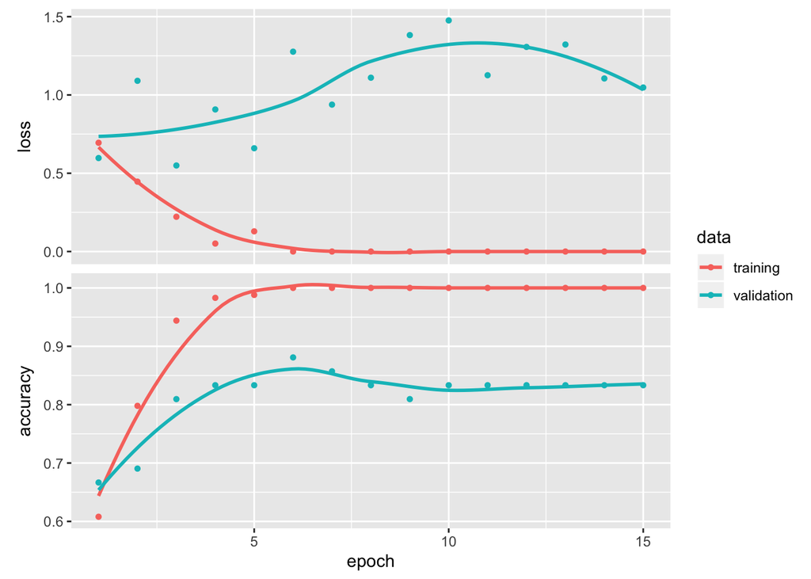